# CVD vs dementia

```r
knitr::opts_chunk$set(echo = TRUE, warning=FALSE, message=F)
```

**Libraries**

```r
#Finngen has old version of forestplot...
#detach("package:forestplot", unload=TRUE)
#install.packages("packages/forestplot_3.1.0.tar.gz", repos=NULL)


library(tidyverse)
library(survival)   # survival analysis
library(data.table) # fread() function
library(gridExtra)  # plots to grid
library(survminer)  # ggbased visualization and extra diagnostics
library(visdat)     # visualization of tibble and na's
library(kableExtra) # Pretty tables
library(tableone)   # Characteristics table
library(forestplot) # Forestplot

fg_pheno_path <- "/finngen/library-red/finngen_R9/phenotype_1.0/data"
data_path <- "data"
fig_path <- "figs2"
#font_size <- 12

source("scripts/functions.R")
```

# 1 Data

## 1.1 Definitions

**Outcomes**

- Any dementia (KRA_PSY_DEMENTIA)
- Alzheimer disease (G6_ALZHEIMER)
- Vascular dementia (F5_VASCDEM)

**Exposures**

- Heart failure (I9_HEARTFAIL_ALLCAUSE)
- Atrial fibrillation (I9_AF)
- Myocardial infarction (I9_MI)
- Peripheral arterial disease (I9_PAD)
- Stroke (I9_STR)
- TIA (I9_TIA)

**Covariates**

Age is not included as we do not have explicit baseline.  
Dementia age is taken account by using age as time scale. Birth year is included to take account cohort effects. Disease covariates are treated as time varied covariates.

- Women, n (%)
- Birth year, (SD)
- Smoking, n (%)

Disease covariates

- Obesity (E4_OBESITY), n (%)
- Hyperlipidemia (E4_HYPERLIPMIX|RX_STATIN), n (%)
- Chronic kidney disease (N14_CHRONKIDNEYDIS), n (%)
- Hypertension (I9_HYPERTENSION), n (%)
- Diabetes (E4_DIABETES), n (%)
- Alcohol abuse (AUD), n (%)

## 1.2 Variable lists

```r
nicenames <- c(DEMENTIA = "Any dementia", ALZHEIMER = "Alzheimer disase", VASCDEM = "Vascular dementia",
               AF_TDC = "Atrial fibrillation", OBESITY_TDC = "Obesity",
               HYPLIP_WIDE_TDC = "Hyperlipidemia", HEARTFAIL_ALLCAUSE_TDC="Heart failure",
               MI_TDC = "Myocardial infarction", CHRONKIDNEYDIS_TDC = "Chronic kidney disease",
               HYPERTENSION_TDC = "Hypertension", DIABETES_TDC = "Diabetes", STR_TDC = "Stroke",
               STR_EMBOLIC_TDC = "Embolic stroke", TIA_TDC = "TIA",
               AUD_TDC = "Alcohol abuse", I9_PAD = "PAD")

#Outcomes
names_ep <- list("DEMENTIA", "ALZHEIMER", "VASCDEM")
ep_age <-   str_replace(unlist(names_ep), "(.*)", "\\1_AGE")

#time dependent variables
tdc_vars <- c("AF_TDC","OBESITY_TDC", "HYPLIP_WIDE_TDC", "HEARTFAIL_ALLCAUSE_TDC", "MI_TDC",
             "CHRONKIDNEYDIS_TDC", "HYPERTENSION_TDC", "DIABETES_TDC", "STR_TDC",
             "TIA_TDC", "AUD_TDC", "PAD_TDC")
tdc_vars_ever <- str_remove(tdc_vars, "_TDC")
tdc_vars_age <- str_replace(tdc_vars, "_TDC", "_AGE")

tdc_vars2 <- c("HEARTFAIL_ALLCAUSE_TDC", "AF_TDC", "MI_TDC", "PAD_TDC", "STR_TDC" , "TIA_TDC")
tdc_vars2_ever <- str_remove(tdc_vars2, "_TDC")
tdc_vars2_year <- str_replace(tdc_vars2, "_TDC", "_YEAR")


#Other covariates
oth_covs <- c("WOMEN", "BIRTH_YEAR", "SMOKED")
oth_covs2 <- c(oth_covs, "OBESITY_TDC",  "HYPLIP_WIDE_TDC", "CHRONKIDNEYDIS_TDC", "HYPERTENSION_TDC", "DIABETES_TDC", "AUD_TDC")

#Study start year
start_year = 1998
```

## 1.3 Preselect phenotype columns

Entries of interest from endpoint file are preselected at ‘rather big machine’, because the original phenotype file is very large.

```r
pheno_cols <- fread("data/variables.txt") %>%
  mutate(col_age = str_glue("{column}_AGE")) %>%
  mutate(col_year = str_glue("{column}_YEAR"))

pheno_cols_all <- c(pheno_cols$column, pheno_cols$col_age, pheno_cols$col_year)

pheno_tmp <- fread(str_glue("{fg_pheno_path}/finngen_R9_endpoint_1.0.txt.gz")) %>%
  select(FINNGENID, FU_END_AGE, all_of(pheno_cols_all))

fwrite(pheno_tmp, 'data/finngen_R9_myvars.tsv.gz', sep='\t')
```

## 1.4 Read in and preprocess

```r
#disease variables
phenotypes <- fread("data/finngen_R9_myvars.tsv.gz") %>%

  #Names are simplified
  rename_at(vars(matches("^[A-Z][0-9]+_")), list(~str_remove(., "^[A-Z][0-9]+_"))) %>%
  rename_at(vars(starts_with('KRA_PSY_')), list(~str_remove(., "KRA_PSY_"))) %>%
  rename_at(vars(starts_with('C_')), list(~str_remove(., "C_"))) %>%
  rename_at(vars(starts_with('DM_')), list(~str_remove(., "DM_"))) %>%
  rename_at(vars(starts_with('RX_')), list(~str_remove(., "RX_"))) %>%

  #Wider definition of hypercholesterolaemia, includes also statin medication
  mutate(HYPLIP_WIDE = if_else(HYPERLIPMIX == 1 | STATIN == 1, 1L, 0L)) %>%
  rowwise() %>%
    mutate(HYPLIP_WIDE_AGE = min(HYPERLIPMIX_AGE, STATIN_AGE)) %>%
  ungroup() %>%

  #Change NA -> 0 for disease variables
  #FinnGen data is constructed for GWASes, where similar diseases need to be removed from controls
  #This does not apply to present study
  mutate_at(c(unlist(names_ep), tdc_vars_ever), ~if_else(is.na(.), 0L, .))

#other covariates
phenomin <- fread(str_glue("{fg_pheno_path}/finngen_R9_minimum_1.0.txt.gz")) %>%
  select("FINNGENID", contains("BL_"), "SEX", "SMOKE3", "SMOKE_AGE", "movedabroad") %>%
  #smoking: ever-never according phenotype minimal file
  mutate(SMOKED = if_else(SMOKE3 == "never", 0, 1)) %>%
  #Approximate birth year calculated from BL_YEAR and BL_AGE
  mutate(BIRTH_YEAR = BL_YEAR - BL_AGE,     #genotyping year and age
         START_AGE = if_else(floor(BIRTH_YEAR) < start_year, start_year-BIRTH_YEAR, 0),
         BIRTH_YEAR = as.integer(floor(BIRTH_YEAR)))

#Imputed sex is from genotyped dataset
sex_in <- fread(str_glue("/finngen/library-red/finngen_R9/analysis_covariates/R9_COV_V1.FID.txt.gz")) %>%
  select(IID, SEX_IMPUTED) %>%
  rename(FINNGENID = IID) %>%
  rename(WOMEN = SEX_IMPUTED)
```

## 1.5 Combine & filter

**All**

```r
df.tmp1 <-phenomin %>%
  right_join(sex_in, by = "FINNGENID") %>%   #This represent official genotyped dataset
  left_join(phenotypes, by = "FINNGENID")
dim(df.tmp1)
```

```
## [1] 377277     86
```

**Remove individual with no “FU_END_AGE” i.e. individuals missing from endpoint-file**

```r
#Remove individual with no "FU_END_AGE" i.e. individuals missing from endpoint-file
df.tmp2 <- df.tmp1 %>%
  filter(!is.na(FU_END_AGE))
dim(df.tmp2)
```

```
## [1] 377277     86
```

**Remove if no smoking record**

```r
#Remove individual if no smoking record
df.tmp3 <- df.tmp2 %>%
  filter(!is.na(SMOKED))
dim(df.tmp3)
```

```
## [1] 221762     86
```

Full register coverage starts from this year.

```r
#Remove individual if any dementia before 'start year'
df <- df.tmp3 %>%
  filter(DEMENTIA_AGE > START_AGE+0.003 & ALZHEIMER_AGE > START_AGE+0.003 & VASCDEM_AGE > START_AGE+0.003)
  #0.003 years = one day; coxph would inteprete very short time difference 0 time followup
dim(df)
```

```
## [1] 218192     86
```

## 1.6 Variables to list by outcome

Minor formatting

```r
#Minor formatting for more clear summaries etc
df <- df %>%
  mutate_at(unlist(names_ep), ~as.integer(as.character(.)) ) %>%
  mutate_at(c(tdc_vars_ever), as.factor) %>%
  select(FINNGENID, all_of(oth_covs), FU_END_AGE, START_AGE, BIRTH_YEAR, all_of(unlist(names_ep)), all_of(ep_age),
         all_of(tdc_vars_ever), all_of(tdc_vars_age), contains("DEATH"), all_of(tdc_vars2_year))
```

As time varied variable

```r
df.list.tdc <- lapply(names_ep, as.null) %>% setNames(names_ep)

for(ep in unlist(names_ep)){

  #ep = "DEMENTIA"
  ep_age_tmp <- as.character(str_glue("{ep}_AGE"))
  dfi <- df  #%>% slice(1:30)
  #print(ep)

  dfi.tmp   <- tmerge(data1=dfi,   data2=dfi, id=FINNGENID, tstart = START_AGE, tstop = get(ep_age_tmp),
                      event=event(get(ep_age_tmp), get(ep)))

  for(var in tdc_vars_ever){
    #var %>% print()
    dfi.tmp  <- tmerge(data1=dfi.tmp, data2=dfi, id=FINNGENID, tdc_var = tdc(get(str_glue("{var}_AGE")))) %>%
      rename(!!str_glue("{var}_TDC") := tdc_var)
  }

  df.list.tdc[[ep]] <- dfi.tmp %>%
    filter(tstop > tstart+0.003) %>%  #0.003 years = one day; coxph would inteprete very short time difference 0 time followup
    mutate(time_test = tstop - tstart)

}
```

**Summaries**

Individuals with outcome before ‘start year’ are removed. Latter table is from ‘dementia’ dataset.

```r
df %>%
  select(FINNGENID, all_of(c(unlist(names_ep), ep_age))) %>%
   mutate_at(unlist(names_ep), as.factor) %>%
   mutate(across(unlist(names_ep),
                list(AGE=~if_else(get(cur_column()) == 1, get(str_glue("{cur_column()}_AGE")), NA_real_)))) %>%
   #mutate(!!ep_age_tmp := if_else(get(ep) == 1, get(ep_age_tmp), NA_real_)) %>%
    summary()
```

```
##   FINNGENID         DEMENTIA   ALZHEIMER  VASCDEM     DEMENTIA_AGE
##  Length:218192      0:208491   0:211869   0:216573   Min.   : 16.19
##  Class :character   1:  9701   1:  6323   1:  1619   1st Qu.: 74.27
##  Mode  :character                                    Median : 79.69
##                                                      Mean   : 78.48
##                                                      3rd Qu.: 84.36
##                                                      Max.   :105.65
##                                                      NA's   :208491
##  ALZHEIMER_AGE     VASCDEM_AGE
##  Min.   : 21.74   Min.   : 21.71
##  1st Qu.: 75.54   1st Qu.: 75.01
##  Median : 80.42   Median : 80.26
##  Mean   : 79.70   Mean   : 79.61
##  3rd Qu.: 84.60   3rd Qu.: 85.11
##  Max.   :105.65   Max.   :102.68
##  NA's   :211869   NA's   :216573
```

```r
df.list.tdc[["DEMENTIA"]] %>%
  select(FINNGENID, all_of(c(oth_covs, tdc_vars, tdc_vars_age))) %>%
  group_by(FINNGENID) %>%
  summarise_all(max) %>%     #For 'tdc variables'  we want maximum (1 if any of the rows have 1), others should be the same in all rows an individual.
  mutate(across(all_of(tdc_vars),
                list(AGE=~if_else( get(cur_column()) == 1, get(str_replace(cur_column(), "_TDC", "_AGE")), NA_real_)))) %>%
  select(-all_of(tdc_vars_age)) %>%
  rename_at(vars(ends_with("TDC_AGE")), ~str_replace(.,"TDC_AGE","AGE")) %>%
  mutate_at(all_of(c("WOMEN", "SMOKED", tdc_vars)), as.factor) %>%
  summary()
```

```
##   FINNGENID         WOMEN        BIRTH_YEAR   SMOKED     AF_TDC     OBESITY_TDC
##  Length:218192      0:102475   Min.   :1900   0:108730   0:191052   0:205781
##  Class :character   1:115717   1st Qu.:1944   1:109462   1: 27140   1: 12411
##  Mode  :character              Median :1956
##                                Mean   :1958
##                                3rd Qu.:1970
##                                Max.   :2017
##
##  HYPLIP_WIDE_TDC HEARTFAIL_ALLCAUSE_TDC MI_TDC     CHRONKIDNEYDIS_TDC
##  0:142534        0:201349               0:202006   0:213115
##  1: 75658        1: 16843               1: 16186   1:  5077
##
##
##
##
##
##  HYPERTENSION_TDC DIABETES_TDC STR_TDC    TIA_TDC    AUD_TDC    PAD_TDC
##  0:154704         0:181248     0:202750   0:207233   0:207918   0:207696
##  1: 63488         1: 36944     1: 15442   1: 10959   1: 10274   1: 10496
##
##
##
##
##
##      AF_AGE        OBESITY_AGE     HYPLIP_WIDE_AGE  HEARTFAIL_ALLCAUSE_AGE
##  Min.   :  0.00   Min.   : 1.05    Min.   : 6.62    Min.   :  0.06
##  1st Qu.: 61.20   1st Qu.:37.85    1st Qu.:53.40    1st Qu.: 62.52
##  Median : 69.55   Median :51.42    Median :60.58    Median : 71.16
##  Mean   : 68.19   Mean   :49.30    Mean   :60.31    Mean   : 69.51
##  3rd Qu.: 76.76   3rd Qu.:60.77    3rd Qu.:67.73    3rd Qu.: 78.22
##  Max.   :102.53   Max.   :91.49    Max.   :98.15    Max.   :100.09
##  NA's   :191052   NA's   :205781   NA's   :142534   NA's   :201349
##      MI_AGE       CHRONKIDNEYDIS_AGE HYPERTENSION_AGE  DIABETES_AGE
##  Min.   : 3.36    Min.   : 0.11      Min.   :  0.01   Min.   :  0.77
##  1st Qu.:57.77    1st Qu.:61.18      1st Qu.: 48.04   1st Qu.: 50.13
##  Median :66.88    Median :71.69      Median : 57.23   Median : 59.74
##  Mean   :66.11    Mean   :68.56      Mean   : 57.49   Mean   : 57.62
##  3rd Qu.:75.01    3rd Qu.:79.36      3rd Qu.: 67.42   3rd Qu.: 67.84
##  Max.   :99.76    Max.   :99.90      Max.   :100.89   Max.   :101.55
##  NA's   :202006   NA's   :213115     NA's   :154704   NA's   :181248
##     STR_AGE          TIA_AGE          AUD_AGE          PAD_AGE
##  Min.   : 0.04    Min.   : 9.56    Min.   :11.17    Min.   :  1.26
##  1st Qu.:60.12    1st Qu.:58.31    1st Qu.:32.12    1st Qu.: 60.55
##  Median :69.17    Median :67.55    Median :43.97    Median : 68.77
##  Mean   :67.45    Mean   :66.08    Mean   :44.71    Mean   : 67.53
##  3rd Qu.:76.37    3rd Qu.:74.95    3rd Qu.:55.96    3rd Qu.: 75.71
##  Max.   :99.64    Max.   :97.70    Max.   :91.97    Max.   :105.38
##  NA's   :202750   NA's   :207233   NA's   :207918   NA's   :207696
```

Exposure year

```r
df %>% select(all_of(tdc_vars2_year)) %>% summary()
```

```
##  HEARTFAIL_ALLCAUSE_YEAR    AF_YEAR          MI_YEAR          PAD_YEAR
##  Min.   :1964            Min.   :1968     Min.   :1970     Min.   :1969
##  1st Qu.:2003            1st Qu.:2005     1st Qu.:2001     1st Qu.:2002
##  Median :2009            Median :2012     Median :2007     Median :2009
##  Mean   :2008            Mean   :2010     Mean   :2007     Mean   :2008
##  3rd Qu.:2015            3rd Qu.:2017     3rd Qu.:2015     3rd Qu.:2016
##  Max.   :2021            Max.   :2021     Max.   :2021     Max.   :2021
##  NA's   :200437          NA's   :190130   NA's   :200230   NA's   :207358
##     STR_YEAR         TIA_YEAR
##  Min.   :1970     Min.   :1969
##  1st Qu.:2004     1st Qu.:2005
##  Median :2011     Median :2011
##  Mean   :2009     Mean   :2010
##  3rd Qu.:2017     3rd Qu.:2017
##  Max.   :2021     Max.   :2021
##  NA's   :201646   NA's   :206936
```

Cumulative incidence of exposures from 1964 to the first dementia

```r
df %>%
  mutate_at(tdc_vars2_ever, ~as.numeric(as.character(.))) %>%
  mutate(across(all_of(tdc_vars2_ever),
              ~if_else(get(str_glue("{cur_column()}_AGE")) >= DEMENTIA_AGE, 0L, .))) %>%
  summarise_at(tdc_vars2_ever, ~round(mean(., na.rm=T),3))
```

| HEARTFAIL_ALLCAUSE | AF | MI | PAD | STR | TIA |
| --- | --- | --- | --- | --- | --- |
| 0.077 | 0.124 | 0.074 | 0.048 | 0.071 | 0.05 |

Cumulative incidence of exposures from 1998 to the first dementia

```r
df.tmp <- df %>%
  mutate_at(tdc_vars2_ever, ~as.numeric(as.character(.))) %>%
  mutate(across(all_of(tdc_vars2_ever),
              ~if_else(get(str_glue("{cur_column()}_AGE")) >= DEMENTIA_AGE, 0L, .)))

lapply(tdc_vars2_ever, function(var) {
  df.tmp  %>%
    filter(get(str_glue("{var}_AGE")) > START_AGE) %>%
    summarise(!!var := round(mean(get(var)),3))
})  %>%
  bind_cols
```

| HEARTFAIL_ALLCAUSE | AF | MI | PAD | STR | TIA |
| --- | --- | --- | --- | --- | --- |
| 0.067 | 0.114 | 0.061 | 0.041 | 0.063 | 0.046 |

Summary, end of follow-up

```r
df %>% filter(DEMENTIA==0) %>% select(END_FU_AGE = DEMENTIA_AGE) %>% summary()
```

```
##    END_FU_AGE
##  Min.   :  3.64
##  1st Qu.: 49.29
##  Median : 63.55
##  Mean   : 60.94
##  3rd Qu.: 74.11
##  Max.   :107.67
```

```r
df %>% filter(DEMENTIA==1) %>% select(END_FU_AGE = DEMENTIA_AGE) %>% summary()
```

```
##    END_FU_AGE
##  Min.   : 16.19
##  1st Qu.: 74.27
##  Median : 79.69
##  Mean   : 78.48
##  3rd Qu.: 84.36
##  Max.   :105.65
```

## 1.7 Characteristics

**Dementia**

```r
ep <- "DEMENTIA"
vars <- c(ep, "END_AGE", oth_covs, tdc_vars)
fact_vars <- c(ep, "WOMEN", "SMOKED", tdc_vars)

df.tmp <- df.list.tdc[[ep]] %>%
  select(FINNGENID, all_of(c(ep, str_glue("{ep}_AGE"), oth_covs, tdc_vars))) %>%
  group_by(FINNGENID) %>%
  summarise_all(max) %>%   #For 'tdc variables'  we want maximum (1 if any of the rows have 1), others should be the same in all rows an individual.
  rename(END_AGE = str_glue("{ep}_AGE"))

CreateTableOne(vars=vars, data=df.tmp, factorVars = fact_vars, test=F) %>%
    print(dropEqual=T, printToggle=F, contDigits=1) %>%
#  row.names(chr_all) <- c(chr_rownames)  %>%
  my.kable()
```

|  | Overall |
| --- | --- |
| n | 218192 |
| DEMENTIA (%) | 9701 ( 4.4) |
| END_AGE (mean (SD)) | 61.7 (17.1) |
| WOMEN (%) | 115717 (53.0) |
| BIRTH_YEAR (mean (SD)) | 1957.6 (18.8) |
| SMOKED (%) | 109462 (50.2) |
| AF_TDC (%) | 27140 (12.4) |
| OBESITY_TDC (%) | 12411 ( 5.7) |
| HYPLIP_WIDE_TDC (%) | 75658 (34.7) |
| HEARTFAIL_ALLCAUSE_TDC (%) | 16843 ( 7.7) |
| MI_TDC (%) | 16186 ( 7.4) |
| CHRONKIDNEYDIS_TDC (%) | 5077 ( 2.3) |
| HYPERTENSION_TDC (%) | 63488 (29.1) |
| DIABETES_TDC (%) | 36944 (16.9) |
| STR_TDC (%) | 15442 ( 7.1) |
| TIA_TDC (%) | 10959 ( 5.0) |
| AUD_TDC (%) | 10274 ( 4.7) |
| PAD_TDC (%) | 10496 ( 4.8) |

**Full characteristics**

**Dementia, full characteristics**

```r
ep <- "DEMENTIA"
vars <- c(ep,  "END_AGE", oth_covs2)
fact_vars <- c(ep, oth_covs2[oth_covs2!="BIRTH_YEAR"])

df.tmp <- df.list.tdc[[ep]] %>%
  select(FINNGENID, all_of(c(ep, str_glue("{ep}_AGE"), oth_covs2, tdc_vars2))) %>%
  group_by(FINNGENID) %>%
  summarise_all(max) %>%   #For 'tdc variables'  we want maximum (1 if any of the rows have 1),
  rename(END_AGE = str_glue("{ep}_AGE")) %>%      #others should be the same in all rows an individual.
  mutate_at(tdc_vars2, ~case_when(.==0 ~ "No", .==1 ~ "Yes") )

tmp.overall <- CreateTableOne(vars=vars, data=df.tmp, factorVars = fact_vars, test=F) %>%
    print(dropEqual=T, printToggle=F, contDigits=1)

tmp.by_exp <- lapply(as.list(tdc_vars2), function(var){
  var_short <- str_extract(var, "^[A-Z]+")
  tmp <- my_char_table(df.tmp, vars, fact_vars, var, c("n",vars))[,c("Yes", "No")]
  colnames(tmp) = c(str_glue("{var_short}"), str_glue("No {var_short}"))
  tmp
})%>% setNames(as.list(tdc_vars2)) %>%
  reduce(cbind)

cbind(tmp.overall, tmp.by_exp) %>%
my.kable()
```

|  | Overall | HEARTFAIL | No HEARTFAIL | AF | No AF | MI | No MI | PAD | No PAD | STR | No STR | TIA | No TIA |
| --- | --- | --- | --- | --- | --- | --- | --- | --- | --- | --- | --- | --- | --- |
| n | 218192 | 16843 | 201349 | 27140 | 191052 | 16186 | 202006 | 10496 | 207696 | 15442 | 202750 | 10959 | 207233 |
| DEMENTIA (%) | 9701 ( 4.4) | 1819 (10.8) | 7882 ( 3.9) | 2292 ( 8.4) | 7409 ( 3.9) | 1513 ( 9.3) | 8188 ( 4.1) | 918 ( 8.7) | 8783 ( 4.2) | 1662 (10.8) | 8039 ( 4.0) | 1069 ( 9.8) | 8632 ( 4.2) |
| END_AGE (mean (SD)) | 61.7 (17.1) | 77.9 (9.8) | 60.4 (16.9) | 76.6 (9.9) | 59.6 (16.9) | 76.2 (9.7) | 60.6 (17.1) | 76.1 (9.7) | 61.0 (17.1) | 75.5 (10.6) | 60.7 (17.1) | 75.1 (10.9) | 61.0 (17.1) |
| WOMEN (%) | 115717 (53.0) | 5485 (32.6) | 110232 (54.7) | 9224 (34.0) | 106493 (55.7) | 4035 (24.9) | 111682 (55.3) | 2887 (27.5) | 112830 (54.3) | 5354 (34.7) | 110363 (54.4) | 4779 (43.6) | 110938 (53.5) |
| BIRTH_YEAR (mean (SD)) | 1957.6 (18.8) | 1938.0 (11.8) | 1959.2 (18.3) | 1941.3 (11.6) | 1959.9 (18.5) | 1940.0 (11.9) | 1959.0 (18.5) | 1939.9 (11.9) | 1958.4 (18.6) | 1941.1 (12.9) | 1958.8 (18.6) | 1943.1 (12.7) | 1958.3 (18.8) |
| SMOKED (%) | 109462 (50.2) | 10651 (63.2) | 98811 (49.1) | 14923 (55.0) | 94539 (49.5) | 10841 (67.0) | 98621 (48.8) | 8086 (77.0) | 101376 (48.8) | 9288 (60.1) | 100174 (49.4) | 5814 (53.1) | 103648 (50.0) |
| OBESITY_TDC (%) | 12411 ( 5.7) | 1854 (11.0) | 10557 ( 5.2) | 2220 ( 8.2) | 10191 ( 5.3) | 1044 ( 6.5) | 11367 ( 5.6) | 818 ( 7.8) | 11593 ( 5.6) | 926 ( 6.0) | 11485 ( 5.7) | 693 ( 6.3) | 11718 ( 5.7) |
| HYPLIP_WIDE_TDC (%) | 75658 (34.7) | 11295 (67.1) | 64363 (32.0) | 17255 (63.6) | 58403 (30.6) | 13364 (82.6) | 62294 (30.8) | 7839 (74.7) | 67819 (32.7) | 11183 (72.4) | 64475 (31.8) | 8266 (75.4) | 67392 (32.5) |
| CHRONKIDNEYDIS_TDC (%) | 5077 ( 2.3) | 2219 (13.2) | 2858 ( 1.4) | 1962 ( 7.2) | 3115 ( 1.6) | 1338 ( 8.3) | 3739 ( 1.9) | 1289 (12.3) | 3788 ( 1.8) | 1029 ( 6.7) | 4048 ( 2.0) | 619 ( 5.6) | 4458 ( 2.2) |
| HYPERTENSION_TDC (%) | 63488 (29.1) | 11514 (68.4) | 51974 (25.8) | 16870 (62.2) | 46618 (24.4) | 9738 (60.2) | 53750 (26.6) | 7038 (67.1) | 56450 (27.2) | 9789 (63.4) | 53699 (26.5) | 6548 (59.7) | 56940 (27.5) |
| DIABETES_TDC (%) | 36944 (16.9) | 6808 (40.4) | 30136 (15.0) | 8355 (30.8) | 28589 (15.0) | 5920 (36.6) | 31024 (15.4) | 4761 (45.4) | 32183 (15.5) | 4881 (31.6) | 32063 (15.8) | 3191 (29.1) | 33753 (16.3) |
| AUD_TDC (%) | 10274 ( 4.7) | 1152 ( 6.8) | 9122 ( 4.5) | 1560 ( 5.7) | 8714 ( 4.6) | 1009 ( 6.2) | 9265 ( 4.6) | 927 ( 8.8) | 9347 ( 4.5) | 1148 ( 7.4) | 9126 ( 4.5) | 607 ( 5.5) | 9667 ( 4.7) |

**Alzheimer’s, full characteristics**

```r
ep <- "ALZHEIMER"
vars <- c(ep,  "END_AGE", oth_covs2)
fact_vars <- c(ep, oth_covs2[oth_covs2!="BIRTH_YEAR"])

df.tmp <- df.list.tdc[[ep]] %>%
  select(FINNGENID, all_of(c(ep, str_glue("{ep}_AGE"), oth_covs2, tdc_vars2))) %>%
  group_by(FINNGENID) %>%
  summarise_all(max) %>%   #For 'tdc variables'  we want maximum (1 if any of the rows have 1), others should be the same in all rows an individual.
  rename(END_AGE = str_glue("{ep}_AGE")) %>%
  mutate_at(tdc_vars2, ~case_when(.==0 ~ "No", .==1 ~ "Yes") )

tmp.overall <- CreateTableOne(vars=vars, data=df.tmp, factorVars = fact_vars, test=F) %>%
    print(dropEqual=T, printToggle=F, contDigits=1)

tmp.by_exp <- lapply(as.list(tdc_vars2), function(var){
  var_short <- str_extract(var, "^[A-Z]+")
  tmp <- my_char_table(df.tmp, vars, fact_vars, var, c("n",vars))[,c("Yes", "No")]
  colnames(tmp) = c(str_glue("{var_short}"), str_glue("No {var_short}"))
  tmp
})%>% setNames(as.list(tdc_vars2)) %>%
  reduce(cbind)

cbind(tmp.overall, tmp.by_exp) %>%
my.kable()
```

|  | Overall | HEARTFAIL | No HEARTFAIL | AF | No AF | MI | No MI | PAD | No PAD | STR | No STR | TIA | No TIA |
| --- | --- | --- | --- | --- | --- | --- | --- | --- | --- | --- | --- | --- | --- |
| n | 218192 | 17047 | 201145 | 27387 | 190805 | 16337 | 201855 | 10619 | 207573 | 15714 | 202478 | 11075 | 207117 |
| ALZHEIMER (%) | 6323 ( 2.9) | 1136 ( 6.7) | 5187 ( 2.6) | 1426 ( 5.2) | 4897 ( 2.6) | 967 ( 5.9) | 5356 ( 2.7) | 568 ( 5.3) | 5755 ( 2.8) | 889 ( 5.7) | 5434 ( 2.7) | 665 ( 6.0) | 5658 ( 2.7) |
| END_AGE (mean (SD)) | 61.8 (17.2) | 78.1 (9.8) | 60.4 (17.0) | 76.7 (9.9) | 59.6 (16.9) | 76.4 (9.7) | 60.6 (17.1) | 76.2 (9.7) | 61.1 (17.2) | 75.7 (10.6) | 60.7 (17.1) | 75.3 (10.9) | 61.1 (17.2) |
| WOMEN (%) | 115717 (53.0) | 5528 (32.4) | 110189 (54.8) | 9300 (34.0) | 106417 (55.8) | 4084 (25.0) | 111633 (55.3) | 2912 (27.4) | 112805 (54.3) | 5446 (34.7) | 110271 (54.5) | 4821 (43.5) | 110896 (53.5) |
| BIRTH_YEAR (mean (SD)) | 1957.6 (18.8) | 1937.9 (11.8) | 1959.2 (18.3) | 1941.2 (11.6) | 1959.9 (18.5) | 1939.9 (11.9) | 1959.0 (18.5) | 1939.9 (11.9) | 1958.5 (18.6) | 1941.0 (12.9) | 1958.8 (18.6) | 1943.1 (12.7) | 1958.3 (18.8) |
| SMOKED (%) | 109462 (50.2) | 10793 (63.3) | 98669 (49.1) | 15076 (55.0) | 94386 (49.5) | 10937 (66.9) | 98525 (48.8) | 8173 (77.0) | 101289 (48.8) | 9450 (60.1) | 100012 (49.4) | 5879 (53.1) | 103583 (50.0) |
| OBESITY_TDC (%) | 12444 ( 5.7) | 1869 (11.0) | 10575 ( 5.3) | 2239 ( 8.2) | 10205 ( 5.3) | 1052 ( 6.4) | 11392 ( 5.6) | 825 ( 7.8) | 11619 ( 5.6) | 936 ( 6.0) | 11508 ( 5.7) | 701 ( 6.3) | 11743 ( 5.7) |
| HYPLIP_WIDE_TDC (%) | 75857 (34.8) | 11423 (67.0) | 64434 (32.0) | 17415 (63.6) | 58442 (30.6) | 13461 (82.4) | 62396 (30.9) | 7914 (74.5) | 67943 (32.7) | 11370 (72.4) | 64487 (31.8) | 8360 (75.5) | 67497 (32.6) |
| CHRONKIDNEYDIS_TDC (%) | 5176 ( 2.4) | 2275 (13.3) | 2901 ( 1.4) | 2009 ( 7.3) | 3167 ( 1.7) | 1371 ( 8.4) | 3805 ( 1.9) | 1320 (12.4) | 3856 ( 1.9) | 1067 ( 6.8) | 4109 ( 2.0) | 639 ( 5.8) | 4537 ( 2.2) |
| HYPERTENSION_TDC (%) | 63763 (29.2) | 11677 (68.5) | 52086 (25.9) | 17061 (62.3) | 46702 (24.5) | 9866 (60.4) | 53897 (26.7) | 7129 (67.1) | 56634 (27.3) | 10001 (63.6) | 53762 (26.6) | 6644 (60.0) | 57119 (27.6) |
| DIABETES_TDC (%) | 37084 (17.0) | 6905 (40.5) | 30179 (15.0) | 8464 (30.9) | 28620 (15.0) | 5984 (36.6) | 31100 (15.4) | 4823 (45.4) | 32261 (15.5) | 4994 (31.8) | 32090 (15.8) | 3241 (29.3) | 33843 (16.3) |
| AUD_TDC (%) | 10348 ( 4.7) | 1187 ( 7.0) | 9161 ( 4.6) | 1603 ( 5.9) | 8745 ( 4.6) | 1030 ( 6.3) | 9318 ( 4.6) | 956 ( 9.0) | 9392 ( 4.5) | 1186 ( 7.5) | 9162 ( 4.5) | 625 ( 5.6) | 9723 ( 4.7) |

**Vascular dementia, full characteristics**

```r
ep <- "VASCDEM"
vars <- c(ep,  "END_AGE", oth_covs2)
fact_vars <- c(ep, oth_covs2[oth_covs2!="BIRTH_YEAR"])

df.tmp <- df.list.tdc[[ep]] %>%
  select(FINNGENID, all_of(c(ep, str_glue("{ep}_AGE"), oth_covs2, tdc_vars2))) %>%
  group_by(FINNGENID) %>%
  summarise_all(max) %>%   #For 'tdc variables'  we want maximum (1 if any of the rows have 1), others should be the same in all rows an individual.
  rename(END_AGE = str_glue("{ep}_AGE")) %>%
  mutate_at(tdc_vars2, ~case_when(.==0 ~ "No", .==1 ~ "Yes") )

tmp.overall <- CreateTableOne(vars=vars, data=df.tmp, factorVars = fact_vars, test=F) %>%
    print(dropEqual=T, printToggle=F, contDigits=1)

tmp.by_exp <- lapply(as.list(tdc_vars2), function(var){
  var_short <- str_extract(var, "^[A-Z]+")
  tmp <- my_char_table(df.tmp, vars, fact_vars, var, c("n",vars))[,c("Yes", "No")]
  colnames(tmp) = c(str_glue("{var_short}"), str_glue("No {var_short}"))
  tmp
})%>% setNames(as.list(tdc_vars2)) %>%
  reduce(cbind)

cbind(tmp.overall, tmp.by_exp) %>%
my.kable()
```

|  | Overall | HEARTFAIL | No HEARTFAIL | AF | No AF | MI | No MI | PAD | No PAD | STR | No STR | TIA | No TIA |
| --- | --- | --- | --- | --- | --- | --- | --- | --- | --- | --- | --- | --- | --- |
| n | 218192 | 17334 | 200858 | 27790 | 190402 | 16566 | 201626 | 10710 | 207482 | 16018 | 202174 | 11200 | 206992 |
| VASCDEM (%) | 1619 ( 0.7) | 415 ( 2.4) | 1204 ( 0.6) | 508 ( 1.8) | 1111 ( 0.6) | 317 ( 1.9) | 1302 ( 0.6) | 234 ( 2.2) | 1385 ( 0.7) | 594 ( 3.7) | 1025 ( 0.5) | 278 ( 2.5) | 1341 ( 0.6) |
| END_AGE (mean (SD)) | 61.9 (17.3) | 78.3 (9.9) | 60.5 (17.0) | 76.9 (10.0) | 59.7 (17.0) | 76.6 (9.8) | 60.7 (17.2) | 76.4 (9.8) | 61.1 (17.2) | 76.0 (10.7) | 60.8 (17.2) | 75.5 (11.0) | 61.1 (17.2) |
| WOMEN (%) | 115717 (53.0) | 5623 (32.4) | 110094 (54.8) | 9466 (34.1) | 106251 (55.8) | 4155 (25.1) | 111562 (55.3) | 2949 (27.5) | 112768 (54.4) | 5556 (34.7) | 110161 (54.5) | 4865 (43.4) | 110852 (53.6) |
| BIRTH_YEAR (mean (SD)) | 1957.6 (18.8) | 1937.8 (11.8) | 1959.3 (18.3) | 1941.1 (11.6) | 1960.0 (18.4) | 1939.8 (11.9) | 1959.0 (18.5) | 1939.8 (11.9) | 1958.5 (18.6) | 1940.8 (12.8) | 1958.9 (18.6) | 1942.9 (12.8) | 1958.3 (18.8) |
| SMOKED (%) | 109462 (50.2) | 10950 (63.2) | 98512 (49.0) | 15280 (55.0) | 94182 (49.5) | 11060 (66.8) | 98402 (48.8) | 8224 (76.8) | 101238 (48.8) | 9606 (60.0) | 99856 (49.4) | 5955 (53.2) | 103507 (50.0) |
| OBESITY_TDC (%) | 12458 ( 5.7) | 1882 (10.9) | 10576 ( 5.3) | 2252 ( 8.1) | 10206 ( 5.4) | 1059 ( 6.4) | 11399 ( 5.7) | 830 ( 7.7) | 11628 ( 5.6) | 937 ( 5.8) | 11521 ( 5.7) | 704 ( 6.3) | 11754 ( 5.7) |
| HYPLIP_WIDE_TDC (%) | 75962 (34.8) | 11596 (66.9) | 64366 (32.0) | 17681 (63.6) | 58281 (30.6) | 13612 (82.2) | 62350 (30.9) | 7987 (74.6) | 67975 (32.8) | 11568 (72.2) | 64394 (31.9) | 8447 (75.4) | 67515 (32.6) |
| CHRONKIDNEYDIS_TDC (%) | 5268 ( 2.4) | 2324 (13.4) | 2944 ( 1.5) | 2054 ( 7.4) | 3214 ( 1.7) | 1401 ( 8.5) | 3867 ( 1.9) | 1347 (12.6) | 3921 ( 1.9) | 1099 ( 6.9) | 4169 ( 2.1) | 648 ( 5.8) | 4620 ( 2.2) |
| HYPERTENSION_TDC (%) | 64145 (29.4) | 11887 (68.6) | 52258 (26.0) | 17368 (62.5) | 46777 (24.6) | 10052 (60.7) | 54093 (26.8) | 7223 (67.4) | 56922 (27.4) | 10219 (63.8) | 53926 (26.7) | 6744 (60.2) | 57401 (27.7) |
| DIABETES_TDC (%) | 37185 (17.0) | 6985 (40.3) | 30200 (15.0) | 8592 (30.9) | 28593 (15.0) | 6079 (36.7) | 31106 (15.4) | 4878 (45.5) | 32307 (15.6) | 5084 (31.7) | 32101 (15.9) | 3280 (29.3) | 33905 (16.4) |
| AUD_TDC (%) | 10359 ( 4.7) | 1198 ( 6.9) | 9161 ( 4.6) | 1614 ( 5.8) | 8745 ( 4.6) | 1038 ( 6.3) | 9321 ( 4.6) | 952 ( 8.9) | 9407 ( 4.5) | 1201 ( 7.5) | 9158 ( 4.5) | 627 ( 5.6) | 9732 ( 4.7) |

# 2 Analysis

## 2.1 Incidence

Incidence rates per 1000 patient-years

```r
#for each outcome...
lapply(names_ep, function(ep){

  df.tmp <- df %>%
      #calculate follow-up time for each individual
      mutate(FU_TIME = get(str_glue("{ep}_AGE")) - START_AGE) %>%
      #Set ourcomes as 0, if after outcome
         #At survival analysis this is taken care when tdc variables are created
      mutate_at(tdc_vars2_ever, ~as.numeric(as.character(.))) %>%
      mutate(across(all_of(tdc_vars2_ever),
                  ~if_else(get(str_glue("{cur_column()}_AGE")) >= get(str_glue("{ep}_AGE")), 0L, .)))

  #for each exposure...
  lapply(tdc_vars2_ever, function(var) {
    name1 = quo_name(str_glue("{var}_1"))
    name0 = quo_name(str_glue("{var}_0"))
    df.tmp %>%
      group_by_at(var) %>%
        #Calculate incidence rate
        summarise(INC=(sum(get(ep))/sum(FU_TIME))*1000) %>%
        #change format
        pivot_wider(names_from=all_of(var), values_from=INC) %>%
        rename(!!name1 := `1`, !!name0 := `0`)
  }) %>%
    bind_cols() %>%
    mutate(outcome=ep)
}) %>%
  bind_rows() %>%
  relocate(outcome) %>%
  rename(HF_0 = HEARTFAIL_ALLCAUSE_0, HF_1 = HEARTFAIL_ALLCAUSE_1 ) %>%
  mutate_if(is.numeric, ~round(.,2)) %>%
  my.kable()
```

| outcome | HF_0 | HF_1 | AF_0 | AF_1 | MI_0 | MI_1 | PAD_0 | PAD_1 | STR_0 | STR_1 | TIA_0 | TIA_1 |
| --- | --- | --- | --- | --- | --- | --- | --- | --- | --- | --- | --- | --- |
| DEMENTIA | 1.78 | 5.89 | 1.77 | 4.15 | 1.84 | 4.99 | 1.93 | 4.72 | 1.81 | 5.64 | 1.91 | 4.71 |
| ALZHEIMER | 1.17 | 3.61 | 1.17 | 2.55 | 1.20 | 3.15 | 1.26 | 2.87 | 1.22 | 2.94 | 1.25 | 2.89 |
| VASCDEM | 0.27 | 1.29 | 0.26 | 0.89 | 0.29 | 1.01 | 0.30 | 1.17 | 0.23 | 1.93 | 0.30 | 1.19 |

## 2.2 Kaplan Meier

### 2.2.1 Models

Let’s see raw data and examine proportional hazard assumption

Surv(tstart, tstop, event) ~ {var_tdc}

```r
ep="DEMENTIA"

km.l.d <-
  lapply(as.list(tdc_vars), function(var){

    my_formula <- str_glue("Surv(tstart, tstop, event) ~ {var}")
    survfit(as.formula(my_formula), data=df.list.tdc[[ep]])

  }) %>% setNames(tdc_vars)


ep <-  "ALZHEIMER"

km.l.a <-
  lapply(as.list(tdc_vars), function(var){

    my_formula <- str_glue("Surv(tstart, tstop, event) ~ {var}")
    survfit(as.formula(my_formula), data=df.list.tdc[[ep]])

  }) %>% setNames(tdc_vars)


ep <- "VASCDEM"

km.l.v <-
  lapply(as.list(tdc_vars), function(var){

    my_formula <- str_glue("Surv(tstart, tstop, event) ~ {var}")
    survfit(as.formula(my_formula), data=df.list.tdc[[ep]])

  }) %>% setNames(tdc_vars)
```

### 2.2.2 Kaplan Meier summary figure

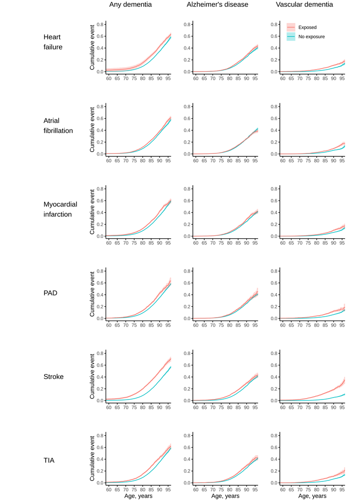

```r
nicenames <- c(DEMENTIA = "Any dementia", ALZHEIMER = "Alzheimer disase", VASCDEM = "Vascular dementia",
               AF_TDC = "Atrial\nfibrillation", OBESITY_TDC = "Obesity",
               HYPLIP_WIDE_TDC = "Hyperlipidemia", HEARTFAIL_ALLCAUSE_TDC="Heart\nfailure",
               MI_TDC = "Myocardial\ninfarction", CHRONKIDNEYDIS_TDC = "Chronic kidney disease",
               HYPERTENSION_TDC = "Hypertension", DIABETES_TDC = "Diabetes", STR_TDC = "Stroke",
               STR_EMBOLIC_TDC = "Embolic stroke", TIA_TDC = "TIA",
               AUD_TDC = "Alcohol abuse", PAD_TDC = "PAD")
fontsize <- 13

#Exposure labels
exp.labs.l <- lapply(as.list(tdc_vars2), function(var){
  text_grob(nicenames[var], just="left", size=fontsize)
})
p0 <- arrangeGrob(grobs=exp.labs.l, ncol=1)

#Dementia
ep="DEMENTIA"
var="AF_TDC"  #Without initialization loop fails, which is strange
my_formula <- str_glue("Surv(tstart, tstop, event) ~ {var}")

plots.kms <-   lapply(as.list(tdc_vars2), function(var){

  my.km <-
    ggsurvplot(km.l.d[[var]], fun="event", conf.int=T, censor=F,
       xlim=c(60,95), ylim=c(0,0.82), break.x.by=5, break.y.by=0.2,
       title = "", xlab = "", legend="none", legend.labs=c('No exposure','Exposed'),
       ggtheme = theme_classic(), palette = c("#00BFC4","#F8766D"), size = 0.5)$plot
}) %>% setNames(as.list(tdc_vars2))
#xlab only to bottom row (TIA)
plots.kms$TIA_TDC <- plots.kms$TIA_TDC +
  xlab("Age, years")

p1 <- arrangeGrob(grobs=plots.kms, ncol=1, top=text_grob("Any dementia", size=fontsize))


#Alzheimer
ep="ALZHEIMER"
var="AF_TDC"  #Without initialization loop fails, which is strange
my_formula <- str_glue("Surv(tstart, tstop, event) ~ {var}")

plots.kms <-   lapply(as.list(tdc_vars2), function(var){

  my.km <-
    ggsurvplot(km.l.a[[var]], fun="event", conf.int=T, censor=F,
       xlim=c(60,95), ylim=c(0,0.82), break.x.by=5, break.y.by=0.2,
       title = " ", xlab = "", ylab="", legend="none", legend.labs=c('No exposure','Exposed'),
       ggtheme = theme_classic(), palette = c("#00BFC4","#F8766D"), size = 0.5)$plot
}) %>% setNames(as.list(tdc_vars2))
#xlab only to bottom row (TIA)
plots.kms$TIA_TDC <- plots.kms$TIA_TDC +
  xlab("Age, years")

p2 <- arrangeGrob(grobs=plots.kms, ncol=1, top=text_grob("Alzheimer's disease", size=fontsize))



#Vascular dementia
ep="VASCDEM"
var="AF_TDC"  #Without initialization loop fails, which is strange
my_formula <- str_glue("Surv(tstart, tstop, event) ~ {var}")

plots.kms <-   lapply(as.list(tdc_vars2), function(var){

  my.km <-
    ggsurvplot(km.l.v[[var]], fun="event", conf.int=T, censor=F,
       xlim=c(60,95), ylim=c(0,0.82), break.x.by=5, break.y.by=0.2,
       title = " ", xlab = "", ylab="", legend="none", legend.labs=c('No exposure','Exposed'),
       ggtheme = theme_classic(), palette = c("#00BFC4","#F8766D"), size = 0.5)$plot
}) %>% setNames(as.list(tdc_vars2))
#xlab only to bottom row (TIA)
plots.kms$TIA_TDC <- plots.kms$TIA_TDC +
  xlab("Age, years")

#Legends fixed
plots.kms$HEARTFAIL_ALLCAUSE_TDC <-
  plots.kms$HEARTFAIL_ALLCAUSE_TDC +
  theme(legend.position = c(0.4,0.82)) +   #Inserted image
  guides(col = guide_legend(reverse = TRUE), fill = guide_legend(reverse = TRUE)) + #Reverse order
  theme(legend.title=element_blank())

p3 <- arrangeGrob(grobs=plots.kms, ncol=1, top=text_grob("Vascular dementia", size=fontsize))

#Combine all
p.grid <- arrangeGrob(p0, p1,p2,p3, ncol=4)


ggsave(file = str_glue("{fig_path}/km.grid.png"), plot = p.grid, height = 13, width = 9, dpi = 300)
ggsave(file = str_glue("{fig_path}/km.grid.eps"), plot = p.grid, device = cairo_ps, height = 13, width =9, dpi = 300)
```

**All curves**

**Dementia**

*KM curves*

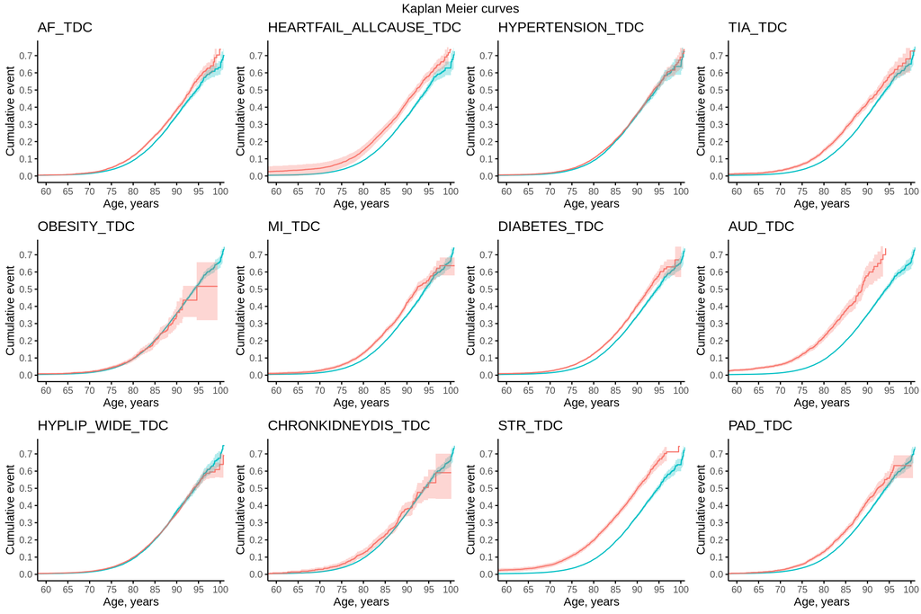

```r
ep="DEMENTIA"
var="AF_TDC"  #Without initialization loop fails, which is strange
my_formula <- str_glue("Surv(tstart, tstop, event) ~ {var}")

plots.kms <-   lapply(as.list(tdc_vars), function(var){

  my.km <-
    ggsurvplot(km.l.d[[var]], fun="event", conf.int=T, censor=F,
       xlim=c(60,99), ylim=c(0,0.75), break.x.by=5, break.y.by=0.1,
       title = var, xlab = "Age, years", legend="none",
       ggtheme = theme_classic(), palette = c("#00BFC4","#F8766D"), size = 0.5)
})

plots.km <- arrange_ggsurvplots(plots.kms, nrow = 3, ncol = 4, title = "Kaplan Meier curves")
```

```r
#ggsave(file = str_glue("{fig_path}/km.r.png"), plot = plots, height = 6, width = 12, dpi = 200)
```

*log(-log) curves*

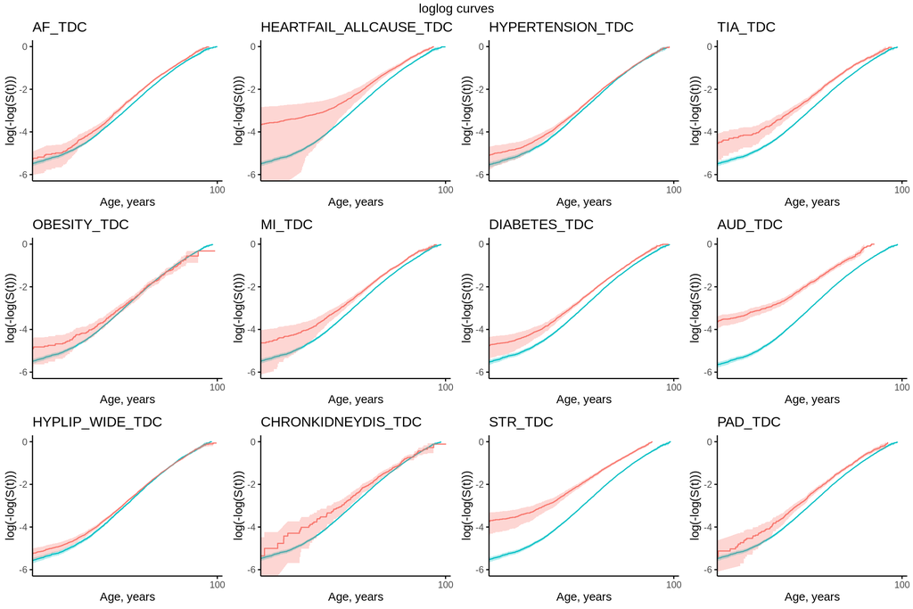

```r
ep="DEMENTIA"
var="AF_TDC"  #Without initialization loop fails, which is strange
my_formula <- str_glue("Surv(tstart, tstop, event) ~ {var}")


plots.kms <-   lapply(as.list(tdc_vars), function(var){

  my.km <-
    ggsurvplot(km.l.d[[var]], fun="cloglog", conf.int=T, censor=F,
       xlim=c(60,99), ylim=c(-6,0),
       title = var, xlab = "Age, years", legend="none",
       ggtheme = theme_classic(), palette = c("#00BFC4","#F8766D"), size = 0.5)
})

plots.km <- arrange_ggsurvplots(plots.kms, nrow = 3, ncol = 4, title = "loglog curves")
```

```r
#ggsave(file = str_glue("{fig_path}/km.r.png"), plot = plots, height = 6, width = 12, dpi = 200)
```

**Alzheimer**

Let’s see raw data and examine proportional hazard assumption

Surv(tstart, tstop, event) ~ {var_tdc}

*KM curves*

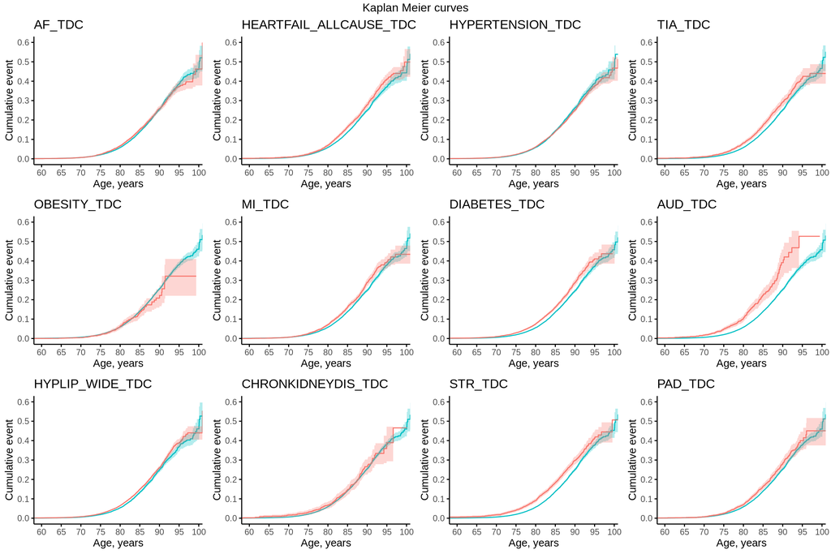

```r
ep <-  "ALZHEIMER"
var="AF_TDC"  #Without initialization loop fails, which is strange
my_formula <- str_glue("Surv(tstart, tstop, event) ~ {var}")


plots.kms <-   lapply(as.list(tdc_vars), function(var){

  my.km <-
    ggsurvplot(km.l.a[[var]], fun="event", conf.int=T, censor=F,
       xlim=c(60,99), ylim=c(0,0.6), break.x.by=5, break.y.by=0.1,
       title = var, xlab = "Age, years", legend="none",
       ggtheme = theme_classic(), palette = c("#00BFC4","#F8766D"), size = 0.5)
})

plots.km <- arrange_ggsurvplots(plots.kms, nrow = 3, ncol = 4, title = "Kaplan Meier curves")
```

```r
#ggsave(file = str_glue("{fig_path}/km.r.png"), plot = plots, height = 6, width = 12, dpi = 200)
```

*log(-log) curves*

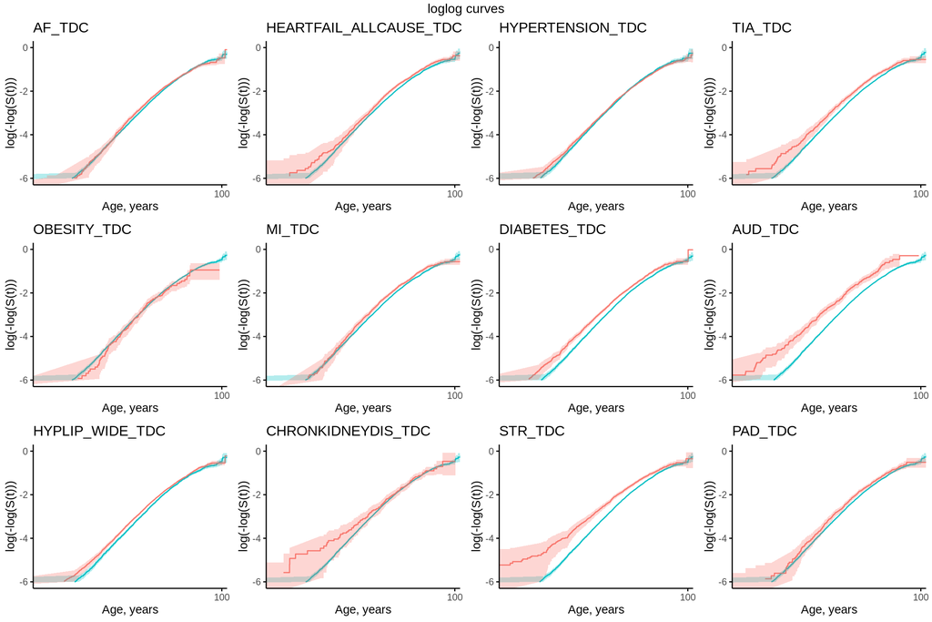

```r
ep <-  "ALZHEIMER"
var="AF_TDC"  #Without initialization loop fails, which is strange
my_formula <- str_glue("Surv(tstart, tstop, event) ~ {var}")


plots.kms <-   lapply(as.list(tdc_vars), function(var){

  my.km <-
    ggsurvplot(km.l.a[[var]], fun="cloglog", conf.int=T, censor=F,
       xlim=c(60,99), ylim=c(-6,0),
       title = var, xlab = "Age, years", legend="none",
       ggtheme = theme_classic(), palette = c("#00BFC4","#F8766D"), size = 0.5)
})

plots.km <- arrange_ggsurvplots(plots.kms, nrow = 3, ncol = 4, title = "loglog curves")
```

```r
#ggsave(file = str_glue("{fig_path}/km.r.png"), plot = plots, height = 6, width = 12, dpi = 200)
```

**Vascular dementia**

Let’s see raw data and examine proportional hazard assumption

Surv(tstart, tstop, event) ~ {var_tdc}

*KM curves*

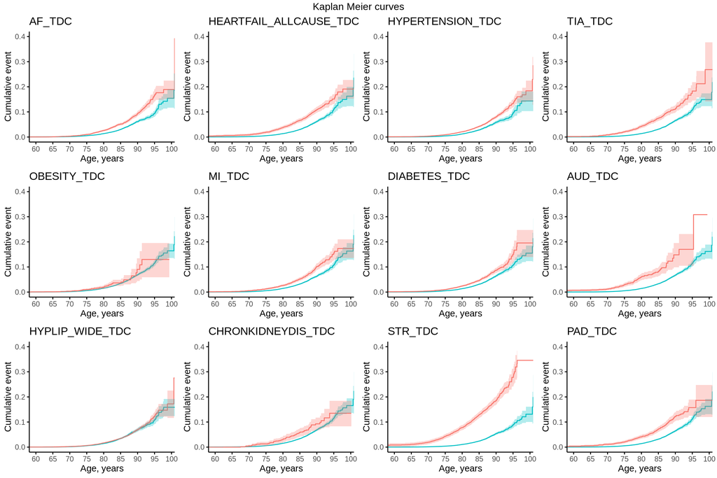

```r
ep <- "VASCDEM"
var="AF_TDC"  #Without initialization loop fails, which is strange
my_formula <- str_glue("Surv(tstart, tstop, event) ~ {var}")


plots.kms <-   lapply(as.list(tdc_vars), function(var){

   my.km <-
    ggsurvplot(km.l.v[[var]], fun="event", conf.int=T, censor=F,
       xlim=c(60,99), ylim=c(0,0.4), break.x.by=5, break.y.by=0.1,
       title = var, xlab = "Age, years", legend="none",
       ggtheme = theme_classic(), palette = c("#00BFC4","#F8766D"), size = 0.5)
})

plots.km <- arrange_ggsurvplots(plots.kms, nrow = 3, ncol = 4, title = "Kaplan Meier curves")
```

```r
#ggsave(file = str_glue("{fig_path}/km.r.png"), plot = plots, height = 6, width = 12, dpi = 200)
```

*log(-log) curves*

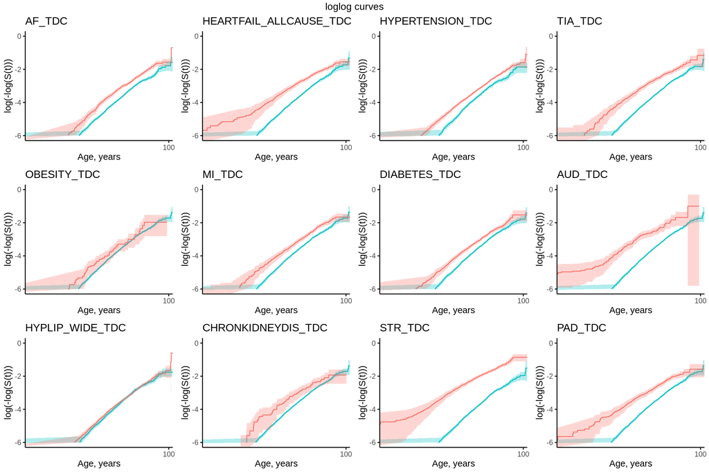

```r
ep <- "VASCDEM"
var="AF_TDC"  #Without initialization loop fails, which is strange
my_formula <- str_glue("Surv(tstart, tstop, event) ~ {var}")


plots.kms <-   lapply(as.list(tdc_vars), function(var){

  my.km <-
    ggsurvplot(km.l.v[[var]], fun="cloglog", conf.int=T, censor=F,
       xlim=c(60,99), ylim=c(-6,0),
       title = var, xlab = "Age, years", legend="none",
       ggtheme = theme_classic(), palette = c("#00BFC4","#F8766D"), size = 0.5)
})

plots.km <- arrange_ggsurvplots(plots.kms, nrow = 3, ncol = 4, title = "loglog curves")
```

```r
#ggsave(file = str_glue("{fig_path}/km.r.png"), plot = plots, height = 6, width = 12, dpi = 200)
```

## 2.3 Cox models

**Models**

Formula:

Surv(tstart, tstop, event) ~ {var} + WOMEN + BIRTH_YEAR + SMOKED + OBESITY_TDC + HYPLIP_WIDE_TDC + CHRONKIDNEYDIS_TDC + HYPERTENSION_TDC + DIABETES_TDC + AUD_TDC

```r
nicenames <- c(DEMENTIA = " Any dementia", ALZHEIMER = " Alzheimer disase", VASCDEM = " Vascular dementia",
               AF_TDC = " Atrial fibrillation", OBESITY_TDC = " Obesity",
               HYPLIP_WIDE_TDC = " Hyperlipidemia", HEARTFAIL_ALLCAUSE_TDC=" Heart failure",
               MI_TDC = " Myocardial infarction", CHRONKIDNEYDIS_TDC = " Chronic kidney disease",
               HYPERTENSION_TDC = " Hypertension", DIABETES_TDC = " Diabetes", STR_TDC = " Stroke",
               STR_EMBOLIC_TDC = " Embolic stroke", TIA_TDC = " TIA",
               AUD_TDC = " Alcohol abuse", PAD_TDC = " PAD")

#Initialize
ep <-  "DEMENTIA"
cx.table.l <- lapply(names_ep, function(x){NULL}) %>% setNames(unlist(names_ep))
cx.full.l  <- lapply(names_ep, function(x){NULL}) %>% setNames(unlist(names_ep))

#For each outcome...
for(ep in unlist(names_ep)){

  #Covariate vector to formula format
  oth_covs2_f <- paste(c(oth_covs2), collapse = " + ")
  #print(ep)

  #Models
  cx.l.tdc<-
    lapply(as.list(tdc_vars2), function(var){

      my_formula <- str_glue("Surv(tstart, tstop, event) ~ {var} + {oth_covs2_f}")
      coxph(as.formula(my_formula), data=df.list.tdc[[ep]])

  }) %>% setNames(tdc_vars2)
 cx.full.l[[ep]] <- cx.l.tdc

  #Number of exposed
  nN <- df.list.tdc[[ep]] %>%
    extract_nN_tdc(ep, tdc_vars2)

  #Table
  cx.table.l[[ep]] <- lapply(tdc_vars2, function(var){
    coefs <- cx.l.tdc[[var]] %>%
      my_extr_coef(ep, var)
  }) %>% setNames(tdc_vars2) %>%
    reduce(bind_rows) %>%
    mutate(p.adj = p.adjust(pval, method = "fdr", n = length(names_ep)*length(tdc_vars2))) %>%
    left_join(nN, by="names") %>%
    select(name, names, est, lower, upper, pval, p.adj, nN_exp, nN_nexp) %>%
    my_tidy_est2() %>%
    rename(outcome=name, variable=names, mean=est, FDR=p.adj) %>%
    mutate(variable=nicenames[variable])
}
```

**Forest plots**

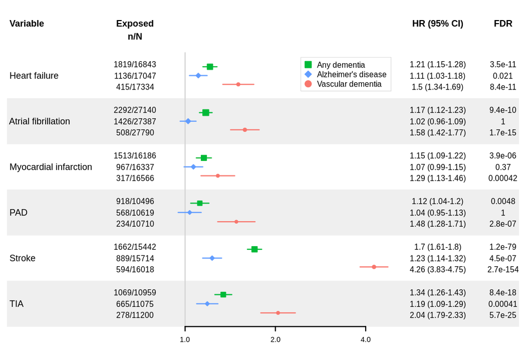

```r
#Stupid hack: forestplot, when grouped, allows only text lines for groups.
#Thus lines within group needs to be combined to same cell and divided by "\n"
tmp <- cx.table.l %>%
  reduce(bind_rows) %>%
  select(variable, outcome, nN_exp, FDR, est_ci) %>%
  pivot_wider(names_from=outcome, values_from=c("est_ci", "FDR", "nN_exp")) %>%
  unite(est_ci, matches("est_ci"), sep="\n") %>%
  unite(FDR, matches("FDR"), sep="\n") %>%
  unite(nN_exp, matches("nN"), sep="\n")

cx.table <- cx.table.l %>%
  reduce(bind_rows) %>%
  select(outcome, variable, mean, lower, upper) %>%
  left_join(tmp, by="variable")

#Forestplot&Table
font.s <- 1.3
font.l <- 1.5
lwd.bar <- 3

forest <- cx.table %>%
  group_by(outcome) %>%
  forestplot(labeltext = c(variable, nN_exp, est_ci, FDR),
             legend = c("Any dementia", "Alzheimer's disease", "Vascular dementia"),
             legend_args = fpLegend(pos = list(x = .8, y = 0.79),
                                    gp = gpar(col = "#CCCCCC")),
             fn.ci_norm = c(fpDrawNormalCI, fpDrawDiamondCI, fpDrawCircleCI),
             #boxsize = .1, # We set the box size to better visualize the type
             line.margin = .25, # We need to add this to avoid crowding
             graph.pos=3,
             xlog=T,
             shapes_gp = fpShapesGp(default = gpar(lwd = lwd.bar)),
             txt_gp = fpTxtGp(ticks = gpar(cex=font.s-.1),
                              label=list(gpar(cex=font.l), gpar(cex=font.s), gpar(cex=font.s), gpar(cex=font.s)),
                              legend=gpar(cex=font.s),
                              summary = gpar(cex=font.l))
             ) %>%
  fp_add_header(variable= " Variable\n", nN_exp="Exposed\nn/N", est_ci = "HR (95% CI)\n", FDR = "FDR\n") %>%
  fp_set_style(box = c("#00BA38", "#619CFF", "#F8766D"),
               line = c("#00BA38", "#619CFF", "#F8766D"))  %>%
  fp_set_zebra_style("#EFEFEF")

png(str_glue("{fig_path}/forest.png"), width = 1050, height = 700)
  forest
dev.off()

pdf(str_glue("{fig_path}/forest.pdf"), width = 14.7, height = 9.8)
  forest
dev.off()
```

**Full output**

```r
cx.full.l
```

```
## $DEMENTIA
## $DEMENTIA$HEARTFAIL_ALLCAUSE_TDC
## Call:
## coxph(formula = as.formula(my_formula), data = df.list.tdc[[ep]])
##
##                             coef exp(coef)  se(coef)      z        p
## HEARTFAIL_ALLCAUSE_TDC  0.190820  1.210242  0.027716  6.885 5.78e-12
## WOMEN                  -0.135683  0.873119  0.023969 -5.661 1.51e-08
## BIRTH_YEAR             -0.014733  0.985375  0.001831 -8.045 8.59e-16
## SMOKED                  0.211777  1.235872  0.023140  9.152  < 2e-16
## OBESITY_TDC            -0.095935  0.908523  0.066158 -1.450   0.1470
## HYPLIP_WIDE_TDC         0.018003  1.018166  0.022610  0.796   0.4259
## CHRONKIDNEYDIS_TDC     -0.057407  0.944210  0.063458 -0.905   0.3657
## HYPERTENSION_TDC        0.038704  1.039462  0.022093  1.752   0.0798
## DIABETES_TDC            0.221091  1.247437  0.024872  8.889  < 2e-16
## AUD_TDC                 0.819870  2.270205  0.045135 18.165  < 2e-16
##
## Likelihood ratio test=814.6  on 10 df, p=< 2.2e-16
## n= 455676, number of events= 9701
##
## $DEMENTIA$AF_TDC
## Call:
## coxph(formula = as.formula(my_formula), data = df.list.tdc[[ep]])
##
##                        coef exp(coef) se(coef)      z        p
## AF_TDC              0.15878   1.17208  0.02499  6.354 2.10e-10
## WOMEN              -0.12458   0.88287  0.02400 -5.191 2.09e-07
## BIRTH_YEAR         -0.01675   0.98339  0.00183 -9.153  < 2e-16
## SMOKED              0.21763   1.24312  0.02312  9.411  < 2e-16
## OBESITY_TDC        -0.07649   0.92636  0.06600 -1.159   0.2465
## HYPLIP_WIDE_TDC     0.02195   1.02219  0.02259  0.972   0.3312
## CHRONKIDNEYDIS_TDC -0.02291   0.97735  0.06307 -0.363   0.7164
## HYPERTENSION_TDC    0.03873   1.03949  0.02211  1.752   0.0798
## DIABETES_TDC        0.23244   1.26167  0.02479  9.377  < 2e-16
## AUD_TDC             0.82396   2.27950  0.04512 18.264  < 2e-16
##
## Likelihood ratio test=808.1  on 10 df, p=< 2.2e-16
## n= 455676, number of events= 9701
##
## $DEMENTIA$MI_TDC
```

[output cut: 291 more lines]

```
##
##                         coef exp(coef)  se(coef)       z        p
## TIA_TDC             0.713642  2.041413  0.067776  10.529  < 2e-16
## WOMEN              -0.418678  0.657916  0.064160  -6.525 6.78e-11
## BIRTH_YEAR         -0.048241  0.952904  0.004512 -10.693  < 2e-16
## SMOKED              0.446903  1.563463  0.059842   7.468 8.14e-14
## OBESITY_TDC         0.187212  1.205883  0.142871   1.310    0.190
## HYPLIP_WIDE_TDC     0.003990  1.003998  0.056615   0.070    0.944
## CHRONKIDNEYDIS_TDC  0.133428  1.142739  0.131818   1.012    0.311
## HYPERTENSION_TDC    0.454031  1.574646  0.054386   8.348  < 2e-16
## DIABETES_TDC        0.294591  1.342577  0.057836   5.094 3.51e-07
## AUD_TDC             0.948865  2.582778  0.097592   9.723  < 2e-16
##
## Likelihood ratio test=667.4  on 10 df, p=< 2.2e-16
## n= 459499, number of events= 1619
```

**All variables in one model**

```r
vars_f <- paste(c(oth_covs,tdc_vars), collapse = " + ")

#Models
cx.l.tdc <- lapply(names_ep, function(ep){

  my_formula <- str_glue("Surv(tstart, tstop, event) ~ {vars_f}")
  coxph(as.formula(my_formula), data=df.list.tdc[[ep]])

}) %>% setNames(names_ep)


#Table
table_tmp <- lapply(names_ep, function(ep){

  my_extr_coef(cx.l.tdc[[ep]], ep, ".*") %>%
    mutate(p.adj = p.adjust(pval, method = "fdr", n = length(names_ep)*length(c(oth_covs,tdc_vars)) )) %>%
    my_tidy_est2()  %>%
    select(names, est_ci, p.adj) %>%
    rename(Variable=names, FDR=p.adj)
})  %>% setNames(names_ep) %>%
  reduce(cbind)

table_tmp <- table_tmp[,-c(4,7)]
names(table_tmp) <- c("Variable", "HR (95% CI)", "FDR","HR (95% CI)", "FDR","HR (95% CI)", "FDR")
table_tmp %>%
  my.kable %>%
  add_header_above(c("", "Any dementia"=2, "Alzheimer's disease"=2, "Vascular dementia"=2 ), bold=T)
```

| Variable | Any dementia HR (95% CI) | Any dementia FDR | Alzheimer’s disease HR (95% CI) | Alzheimer’s disease FDR | Vascular dementia HR (95% CI) | Vascular dementia FDR |
| --- | --- | --- | --- | --- | --- | --- |
| WOMEN | 0.9 (0.85-0.94) | 3.8e-05 | 0.93 (0.88-0.98) | 0.07 | 0.71 (0.63-0.81) | 1.1e-06 |
| BIRTH_YEAR | 0.99 (0.98-0.99) | 8.1e-14 | 1 (0.99-1) | 1 | 0.96 (0.95-0.97) | 3e-20 |
| SMOKED | 1.22 (1.17-1.28) | 9.3e-17 | 1.19 (1.13-1.26) | 1.6e-08 | 1.48 (1.31-1.67) | 1.1e-09 |
| AF_TDC | 1.08 (1.03-1.14) | 0.0097 | 0.98 (0.92-1.05) | 1 | 1.31 (1.16-1.47) | 4.5e-05 |
| OBESITY_TDC | 0.91 (0.8-1.04) | 0.57 | 0.87 (0.73-1.02) | 0.41 | 1.14 (0.86-1.5) | 1 |
| HYPLIP_WIDE_TDC | 0.94 (0.9-0.99) | 0.05 | 1.07 (1.02-1.14) | 0.07 | 0.83 (0.74-0.93) | 0.0057 |
| HEARTFAIL_ALLCAUSE_TDC | 1.12 (1.06-1.19) | 0.00041 | 1.09 (1.02-1.18) | 0.074 | 1.23 (1.08-1.39) | 0.0064 |
| MI_TDC | 1.1 (1.04-1.17) | 0.0052 | 1.04 (0.97-1.12) | 1 | 1.12 (0.98-1.28) | 0.35 |
| CHRONKIDNEYDIS_TDC | 0.92 (0.82-1.05) | 0.7 | 0.92 (0.79-1.07) | 1 | 0.98 (0.75-1.27) | 1 |
| HYPERTENSION_TDC | 0.99 (0.95-1.04) | 1 | 0.93 (0.88-0.98) | 0.044 | 1.34 (1.2-1.49) | 1.3e-06 |
| DIABETES_TDC | 1.25 (1.19-1.31) | 1.5e-17 | 1.21 (1.14-1.29) | 7.6e-09 | 1.28 (1.14-1.44) | 0.00011 |
| STR_TDC | 1.62 (1.53-1.72) | 1.2e-61 | 1.2 (1.11-1.29) | 3e-05 | 3.85 (3.44-4.3) | 1.6e-122 |
| TIA_TDC | 1.17 (1.09-1.25) | 4.7e-05 | 1.13 (1.04-1.23) | 0.036 | 1.32 (1.15-1.51) | 0.00044 |
| AUD_TDC | 2.18 (2-2.39) | 2.5e-65 | 1.65 (1.45-1.87) | 4.5e-13 | 2.23 (1.84-2.7) | 3.7e-15 |
| PAD_TDC | 1.06 (0.99-1.14) | 0.44 | 1.01 (0.92-1.1) | 1 | 1.27 (1.1-1.47) | 0.0056 |